# Lab 1 Gapminder Visualization

Author

Miranda Jeng

### Task 1

Q1

- x axis: Income
- y axis: Life expectancy
- Color: Region(eg. Africa, Asis, Europe, etc.)
- Size: Population(size of bubbles)
- Time: Year (using the sliding bar at the bottom)

Q2

```python
# import dataset
import pandas as pd

df = pd.read_csv('q1data.csv')
df = df.dropna()
```

```python
## import other nessecary functions
import numpy as np
from plotnine import(
    ggplot, geom_histogram, geom_boxplot, geom_density, aes, labs, geom_point, annotate, theme, scale_fill_manual, scale_color_manual, scale_x_log10, scale_x_continuous,
    scale_y_continuous,scale_y_log10, scale_size, geom_hline, geom_vline, theme_matplotlib, theme_set)
theme_set(theme_matplotlib())
```

```python
color_mapping = {
    'asia': 'red',
    'africa': 'darkturquoise',
    'americas': 'lime',
    'europe': 'gold'
}
x_breaks = [500, 1000, 2000, 4000, 8000, 16000, 32000, 64000]
y_breaks = [10, 30, 40, 50, 60, 70, 80, 90]
```

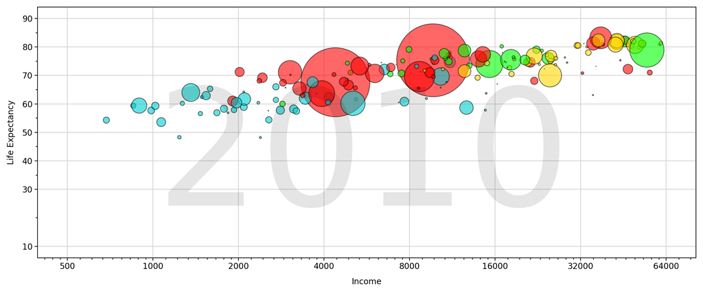

```python
## recreate the bubble chart
p1 = (ggplot(df, aes(x="income", y="life_exp", size="population", fill="four_regions"))
     + geom_hline(yintercept=y_breaks, color='lightgrey', size=0.5)
     + geom_vline(xintercept=x_breaks, color='lightgrey', size=0.5)
     + geom_point(alpha=0.6)
     + scale_fill_manual(values=color_mapping)
     + scale_x_log10(limits=(500, 64000), breaks=x_breaks)
     + scale_y_continuous(limits=(10, 90), breaks=y_breaks)
     + scale_size(range=[-1, 50])
     + labs(x="Income", y="Life Expectancy")
     + theme(figure_size=(12, 5), legend_position="none")
     + annotate("text", label="2010", x=5500, y=40, size=200, alpha=0.1, color="black")
)
p1
```

Q3

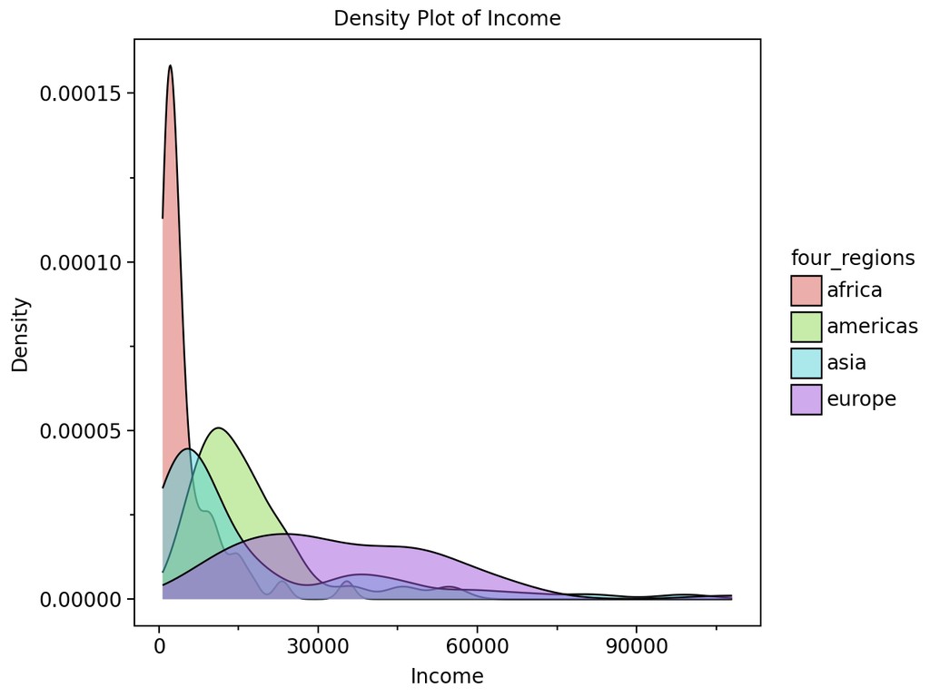

```python
p1_1 = (
    ggplot(df, aes(x='income', fill='four_regions')) +
    geom_density(alpha=0.5) +
    labs(x='Income', y='Density', title='Density Plot of Income')
)
p1_1
```

Q4

Density plot isn’t as good as bubble chart in this case because it measure the density of one variable(income) and is not able to reflect the life_exp and population variables. It is better when use to measure distribution. Since we are interested in three variables, it’s better to use bubble chart

### Task 2

Q1

- x axis: Exports(% of GDP)
- y axis: Imports(% of GDP)
- Color: Region(eg. Africa, Asis, Europe, etc.)
- Size: Energy Use(size of bubbles)
- Time: Year (using the sliding bar at the bottom)

Q2

```python
## import dataset
df = pd.read_csv('q2data.csv')
df = df.dropna()
```

```python
color_mapping = {
    'asia': 'red',
    'africa': 'darkturquoise',
    'americas': 'lime',
    'europe': 'gold'
}
x_breaks = [0, 20, 40, 60, 80, 100, 120, 140, 160, 180, 200, 220]
y_breaks = [0, 50, 100, 150, 200, 250, 300, 350, 400]
```

```python
def convert_to_float(value):
    if 'k' in value:
        return float(value.replace('k', '')) * 1000
    return float(value)

df['energy'] = df['energy'].apply(convert_to_float)
```

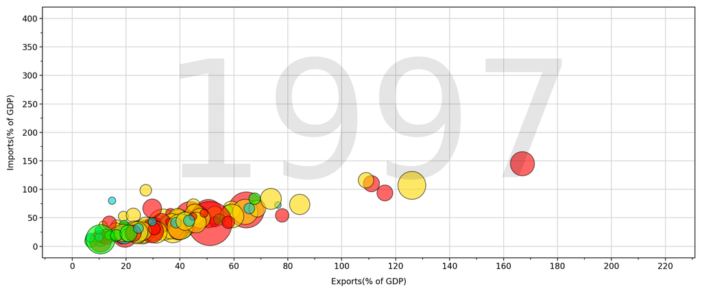

```python
p2 = (ggplot(df, aes(x="exports", y="imports", size="energy", fill="four_regions"))
     + geom_hline(yintercept=y_breaks, color='lightgrey', size=0.5)
     + geom_vline(xintercept=x_breaks, color='lightgrey', size=0.5)
     + geom_point(alpha=0.6)
     + scale_fill_manual(values=color_mapping)
     + scale_x_continuous(limits=(0, 220), breaks=x_breaks)
     + scale_y_continuous(limits=(0, 400), breaks=y_breaks)
     + scale_size(range=[2, 30])
     + labs(x="Exports(% of GDP)", y="Imports(% of GDP)")
     + theme(figure_size=(12, 5), legend_position="none")
     + annotate("text", label="1997", x=110, y=200, size=200, alpha=0.1, color="black")
)
p2
```

Q3

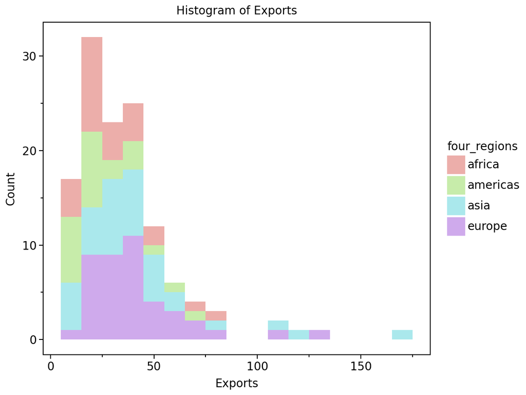

```python
p2_1 = (
    ggplot(df, aes(x='exports', fill='four_regions')) +
    geom_histogram(alpha=0.5, binwidth=10) +  # Adjust binwidth as necessary
    labs(x='Exports', y='Count', title='Histogram of Exports')
)
p2_1
```

Q4

HIstgram is mostly used when we’re interested in distribution of a variable, in this case, we can learn the counts of exports through histogram, but it doesn’t show the relationship with the other variabels that we can actually see measure if using bubble chart

### Task 3

Q1

- x axis: Individuals using the Internet
- y axis: GDP per capita
- Color: Region(eg. Africa, Asis, Europe, etc.)
- Size: Income(size of bubbles)
- Time: Year (using the sliding bar at the bottom)

Q2

```python
## import dataset
df = pd.read_csv('q3data.csv')
df = df.dropna()
```

```python
color_mapping = {
    'asia': 'red',
    'africa': 'darkturquoise',
    'americas': 'lime',
    'europe': 'gold'
}
x_breaks = [0, 10, 20, 30, 40, 50, 60, 70, 80, 90]
y_breaks = [200, 500, 1000, 2000, 5000, 10000, 20000, 50000, 100000]
```

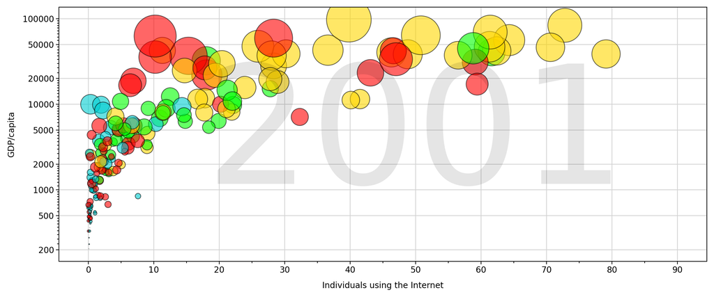

```python
p3 = (ggplot(df, aes(x="internet_users", y="gdp", size="income", fill="four_regions"))
     + geom_hline(yintercept=y_breaks, color='lightgrey', size=0.5)
     + geom_vline(xintercept=x_breaks, color='lightgrey', size=0.5)
     + geom_point(alpha=0.6)
     + scale_fill_manual(values=color_mapping)
     + scale_x_continuous(limits=(0, 90), breaks=x_breaks)
     + scale_y_log10(limits=(200, 100000), breaks=y_breaks)
     + scale_size(range=[-1, 30])
     + labs(x="Individuals using the Internet", y="GDP/capita")
     + theme(figure_size=(12, 5),legend_position="none")
     + annotate("text", label="2001", x=50, y=4000, size=200, alpha=0.1, color="black")
)
p3
```

Q3

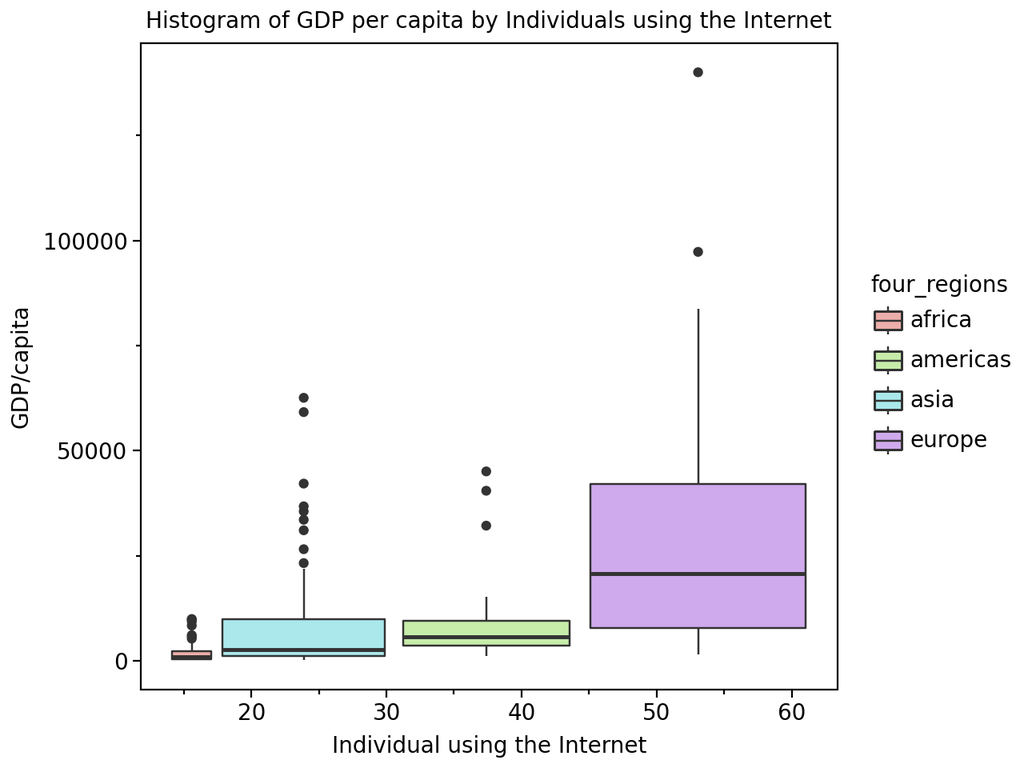

```python
# create a histogram
p3_1 = (
    ggplot(df, aes(x='internet_users', y='gdp', fill='four_regions')) +
    geom_boxplot(alpha=0.5) +
    labs(x='Individual using the Internet', y='GDP/capita', title='Histogram of GDP per capita by Individuals using the Internet')
)
p3_1
```

Q4

Boxplot only summarize one single continuous variable, and is usually useful when trying to examine outliers. In this case, it’s not able to show three different variables and the plot doesn’t make much sense. Also, since the data range varies, it’s hard to read.